# Project: Investigate a Dataset: FBI Background Check Records In Context

- Introduction
- Data Wrangling
- Exploratory Data Analysis
- Conclusions

## Introduction

> **Task**: To find relationships between background checks, purchases, and population data subsets.

Starting and leading questions:

- What census data is most associated with high gun per capita?
- Which states have had the highest growth in gun registrations?
- What is the overall trend of gun purchases?

The data comes from the FBI's National Instant Criminal Background Check System. The NICS is used by to determine whether a prospective buyer is eligible to buy firearms or explosives. Gun shops call into this system to ensure that each customer does not have a criminal record or isn’t otherwise ineligible to make a purchase. The data has been supplemented with state level data from census.gov.

What is the NICS Process?

When a person tries to buy a firearm, the seller, known as a Federal Firearms Licensee (FFL), contacts NICS electronically or by phone. The prospective buyer fills out the ATF form, and the FFL relays that information to the NICS. The NICS staff performs a background check on the buyer. That background check verifies the buyer does not have a criminal record or isn't otherwise ineligible to purchase or own a firearm. Since launching in 1998, more than 300 million checks have been done, leading to more than 1.5 million denials.

The NICS data is found in one sheet of an .xlsx file. It contains the number of firearm checks by month, state, and type. The U.S. census data is found in a .csv file. It contains several variables at the state level. Most variables just have one data point per state (2016), but a few have data for more than one year.

```python
# Use this cell to set up import statements for all of the packages that you
#   plan to use.

# Remember to include a 'magic word' so that your visualizations are plotted
#   inline with the notebook. See this page for more:
#   http://ipython.readthedocs.io/en/stable/interactive/magics.html

import pandas as pd
import numpy as np
import matplotlib.pyplot as plt
%matplotlib inline
```

## Data Wrangling

> **Tip**: In this section of the report, you will load in the data, check for cleanliness, and then trim and clean your dataset for analysis. Make sure that you document your steps carefully and justify your cleaning decisions.

### General Properties

```python
# Load your data and print out a few lines. Perform operations to inspect data
#   types and look for instances of missing or possibly errant data.
gun_df = pd.read_excel('gun-data.xlsx')
census_df = pd.read_csv('u.s.-census-data.csv')
```

```python
gun_df.head(3)
```

|  | month | state | permit | permit_recheck | handgun | long_gun | other | multiple | admin | prepawn_handgun | ... | returned_other | rentals_handgun | rentals_long_gun | private_sale_handgun | private_sale_long_gun | private_sale_other | return_to_seller_handgun | return_to_seller_long_gun | return_to_seller_other | totals |
| --- | --- | --- | --- | --- | --- | --- | --- | --- | --- | --- | --- | --- | --- | --- | --- | --- | --- | --- | --- | --- | --- |
| 0 | 2017-09 | Alabama | 16717.0 | 0.0 | 5734.0 | 6320.0 | 221.0 | 317 | 0.0 | 15.0 | ... | 0.0 | 0.0 | 0.0 | 9.0 | 16.0 | 3.0 | 0.0 | 0.0 | 3.0 | 32019 |
| 1 | 2017-09 | Alaska | 209.0 | 2.0 | 2320.0 | 2930.0 | 219.0 | 160 | 0.0 | 5.0 | ... | 0.0 | 0.0 | 0.0 | 17.0 | 24.0 | 1.0 | 0.0 | 0.0 | 0.0 | 6303 |
| 2 | 2017-09 | Arizona | 5069.0 | 382.0 | 11063.0 | 7946.0 | 920.0 | 631 | 0.0 | 13.0 | ... | 0.0 | 0.0 | 0.0 | 38.0 | 12.0 | 2.0 | 0.0 | 0.0 | 0.0 | 28394 |

3 rows × 27 columns

```python
census_df.head(3)
```

|  | Fact | Fact Note | Alabama | Alaska | Arizona | Arkansas | California | Colorado | Connecticut | Delaware | ... | South Dakota | Tennessee | Texas | Utah | Vermont | Virginia | Washington | West Virginia | Wisconsin | Wyoming |
| --- | --- | --- | --- | --- | --- | --- | --- | --- | --- | --- | --- | --- | --- | --- | --- | --- | --- | --- | --- | --- | --- |
| 0 | Population estimates, July 1, 2016, (V2016) | NaN | 4,863,300 | 741,894 | 6,931,071 | 2,988,248 | 39,250,017 | 5,540,545 | 3,576,452 | 952,065 | ... | 865454 | 6651194 | 27,862,596 | 3,051,217 | 624,594 | 8,411,808 | 7,288,000 | 1,831,102 | 5,778,708 | 585,501 |
| 1 | Population estimates base, April 1, 2010, (V2... | NaN | 4,780,131 | 710,249 | 6,392,301 | 2,916,025 | 37,254,522 | 5,029,324 | 3,574,114 | 897,936 | ... | 814195 | 6346298 | 25,146,100 | 2,763,888 | 625,741 | 8,001,041 | 6,724,545 | 1,853,011 | 5,687,289 | 563,767 |
| 2 | Population, percent change - April 1, 2010 (es... | NaN | 1.70% | 4.50% | 8.40% | 2.50% | 5.40% | 10.20% | 0.10% | 6.00% | ... | 0.063 | 0.048 | 10.80% | 10.40% | -0.20% | 5.10% | 8.40% | -1.20% | 1.60% | 3.90% |

3 rows × 52 columns

```python
census_df.info()
```

```
<class 'pandas.core.frame.DataFrame'>
RangeIndex: 85 entries, 0 to 84
Data columns (total 52 columns):
Fact              80 non-null object
Fact Note         28 non-null object
Alabama           65 non-null object
Alaska            65 non-null object
Arizona           65 non-null object
Arkansas          65 non-null object
California        65 non-null object
Colorado          65 non-null object
Connecticut       65 non-null object
Delaware          65 non-null object
Florida           65 non-null object
Georgia           65 non-null object
Hawaii            65 non-null object
Idaho             65 non-null object
Illinois          65 non-null object
Indiana           65 non-null object
Iowa              65 non-null object
Kansas            65 non-null object
Kentucky          65 non-null object
Louisiana         65 non-null object
Maine             65 non-null object
Maryland          65 non-null object
Massachusetts     65 non-null object
Michigan          65 non-null object
Minnesota         65 non-null object
Mississippi       65 non-null object
Missouri          65 non-null object
Montana           65 non-null object
Nebraska          65 non-null object
Nevada            65 non-null object
New Hampshire     65 non-null object
New Jersey        65 non-null object
New Mexico        65 non-null object
New York          65 non-null object
North Carolina    65 non-null object
North Dakota      65 non-null object
Ohio              65 non-null object
Oklahoma          65 non-null object
Oregon            65 non-null object
Pennsylvania      65 non-null object
Rhode Island      65 non-null object
South Carolina    65 non-null object
South Dakota      65 non-null object
Tennessee         65 non-null object
Texas             65 non-null object
Utah              65 non-null object
Vermont           65 non-null object
Virginia          65 non-null object
Washington        65 non-null object
West Virginia     65 non-null object
Wisconsin         65 non-null object
Wyoming           65 non-null object
dtypes: object(52)
memory usage: 34.7+ KB
```

```python
gun_df.info()
```

```
<class 'pandas.core.frame.DataFrame'>
RangeIndex: 12485 entries, 0 to 12484
Data columns (total 27 columns):
month                        12485 non-null object
state                        12485 non-null object
permit                       12461 non-null float64
permit_recheck               1100 non-null float64
handgun                      12465 non-null float64
long_gun                     12466 non-null float64
other                        5500 non-null float64
multiple                     12485 non-null int64
admin                        12462 non-null float64
prepawn_handgun              10542 non-null float64
prepawn_long_gun             10540 non-null float64
prepawn_other                5115 non-null float64
redemption_handgun           10545 non-null float64
redemption_long_gun          10544 non-null float64
redemption_other             5115 non-null float64
returned_handgun             2200 non-null float64
returned_long_gun            2145 non-null float64
returned_other               1815 non-null float64
rentals_handgun              990 non-null float64
rentals_long_gun             825 non-null float64
private_sale_handgun         2750 non-null float64
private_sale_long_gun        2750 non-null float64
private_sale_other           2750 non-null float64
return_to_seller_handgun     2475 non-null float64
return_to_seller_long_gun    2750 non-null float64
return_to_seller_other       2255 non-null float64
totals                       12485 non-null int64
dtypes: float64(23), int64(2), object(2)
memory usage: 2.6+ MB
```

### Data Cleaning Time

```python
#Step 4: Extract Year and months column based on Month in Gun data
# and convert data type from string to numeric
#Assign the data before '-' in month column to year column
gun_df['year']=gun_df['month'].apply(lambda x: x.split("-")[0]).astype(int)
gun_df['year'].unique()
```

```
array([2017, 2016, 2015, 2014, 2013, 2012, 2011, 2010, 2009, 2008, 2007,
       2006, 2005, 2004, 2003, 2002, 2001, 2000, 1999, 1998])
```

```python
#Assign the data after '-' in month column to year column
gun_df['months'] = gun_df['month'].apply(lambda x: x.split("-")[1]).astype(int)
gun_df['months'].unique()
```

```
array([ 9,  8,  7,  6,  5,  4,  3,  2,  1, 12, 11, 10])
```

```python
gun_df.head()
```

|  | month | state | permit | permit_recheck | handgun | long_gun | other | multiple | admin | prepawn_handgun | ... | rentals_long_gun | private_sale_handgun | private_sale_long_gun | private_sale_other | return_to_seller_handgun | return_to_seller_long_gun | return_to_seller_other | totals | year | months |
| --- | --- | --- | --- | --- | --- | --- | --- | --- | --- | --- | --- | --- | --- | --- | --- | --- | --- | --- | --- | --- | --- |
| 0 | 2017-09 | Alabama | 16717.0 | 0.0 | 5734.0 | 6320.0 | 221.0 | 317 | 0.0 | 15.0 | ... | 0.0 | 9.0 | 16.0 | 3.0 | 0.0 | 0.0 | 3.0 | 32019 | 2017 | 9 |
| 1 | 2017-09 | Alaska | 209.0 | 2.0 | 2320.0 | 2930.0 | 219.0 | 160 | 0.0 | 5.0 | ... | 0.0 | 17.0 | 24.0 | 1.0 | 0.0 | 0.0 | 0.0 | 6303 | 2017 | 9 |
| 2 | 2017-09 | Arizona | 5069.0 | 382.0 | 11063.0 | 7946.0 | 920.0 | 631 | 0.0 | 13.0 | ... | 0.0 | 38.0 | 12.0 | 2.0 | 0.0 | 0.0 | 0.0 | 28394 | 2017 | 9 |
| 3 | 2017-09 | Arkansas | 2935.0 | 632.0 | 4347.0 | 6063.0 | 165.0 | 366 | 51.0 | 12.0 | ... | 0.0 | 13.0 | 23.0 | 0.0 | 0.0 | 2.0 | 1.0 | 17747 | 2017 | 9 |
| 4 | 2017-09 | California | 57839.0 | 0.0 | 37165.0 | 24581.0 | 2984.0 | 0 | 0.0 | 0.0 | ... | 0.0 | 0.0 | 0.0 | 0.0 | 0.0 | 0.0 | 0.0 | 123506 | 2017 | 9 |

5 rows × 29 columns

```python
# Lets find a better name for Fact
census_df.rename(columns={'Fact':'Population'}, inplace=True)
# The Fact Note column is useless
census_df.drop(columns = ['Fact Note'], inplace=True)
census_df.head(1)
```

|  | Population | Alabama | Alaska | Arizona | Arkansas | California | Colorado | Connecticut | Delaware | Florida | ... | South Dakota | Tennessee | Texas | Utah | Vermont | Virginia | Washington | West Virginia | Wisconsin | Wyoming |
| --- | --- | --- | --- | --- | --- | --- | --- | --- | --- | --- | --- | --- | --- | --- | --- | --- | --- | --- | --- | --- | --- |
| 0 | Population estimates, July 1, 2016, (V2016) | 4,863,300 | 741,894 | 6,931,071 | 2,988,248 | 39,250,017 | 5,540,545 | 3,576,452 | 952,065 | 20,612,439 | ... | 865454 | 6651194 | 27,862,596 | 3,051,217 | 624,594 | 8,411,808 | 7,288,000 | 1,831,102 | 5,778,708 | 585,501 |

1 rows × 51 columns

```python
#find duplicated rows
gun_df.duplicated().sum()
```

```
0
```

```python
census_df.duplicated().sum()
```

```
4
```

```python
#Lets see what some of those duplicates look like
census_df[census_df.duplicated(keep=False)]
```

|  | Population | Alabama | Alaska | Arizona | Arkansas | California | Colorado | Connecticut | Delaware | Florida | ... | South Dakota | Tennessee | Texas | Utah | Vermont | Virginia | Washington | West Virginia | Wisconsin | Wyoming |
| --- | --- | --- | --- | --- | --- | --- | --- | --- | --- | --- | --- | --- | --- | --- | --- | --- | --- | --- | --- | --- | --- |
| 65 | NaN | NaN | NaN | NaN | NaN | NaN | NaN | NaN | NaN | NaN | ... | NaN | NaN | NaN | NaN | NaN | NaN | NaN | NaN | NaN | NaN |
| 67 | NaN | NaN | NaN | NaN | NaN | NaN | NaN | NaN | NaN | NaN | ... | NaN | NaN | NaN | NaN | NaN | NaN | NaN | NaN | NaN | NaN |
| 70 | NaN | NaN | NaN | NaN | NaN | NaN | NaN | NaN | NaN | NaN | ... | NaN | NaN | NaN | NaN | NaN | NaN | NaN | NaN | NaN | NaN |
| 75 | NaN | NaN | NaN | NaN | NaN | NaN | NaN | NaN | NaN | NaN | ... | NaN | NaN | NaN | NaN | NaN | NaN | NaN | NaN | NaN | NaN |
| 81 | NaN | NaN | NaN | NaN | NaN | NaN | NaN | NaN | NaN | NaN | ... | NaN | NaN | NaN | NaN | NaN | NaN | NaN | NaN | NaN | NaN |

5 rows × 51 columns

```python
census_df.drop_duplicates(inplace=True)
```

```python
# double check to see if duplicates are gone
census_df.duplicated().sum()
```

```
0
```

```python
# There are alot of rows in the census data that we might not need for answering our questions.
# Hence lets keep on the dates 2016 and 2010.
census_df_pop = census_df.iloc[0:4, :]
census_df_pop.head()
```

|  | Population | Alabama | Alaska | Arizona | Arkansas | California | Colorado | Connecticut | Delaware | Florida | ... | South Dakota | Tennessee | Texas | Utah | Vermont | Virginia | Washington | West Virginia | Wisconsin | Wyoming |
| --- | --- | --- | --- | --- | --- | --- | --- | --- | --- | --- | --- | --- | --- | --- | --- | --- | --- | --- | --- | --- | --- |
| 0 | Population estimates, July 1, 2016, (V2016) | 4,863,300 | 741,894 | 6,931,071 | 2,988,248 | 39,250,017 | 5,540,545 | 3,576,452 | 952,065 | 20,612,439 | ... | 865454 | 6651194 | 27,862,596 | 3,051,217 | 624,594 | 8,411,808 | 7,288,000 | 1,831,102 | 5,778,708 | 585,501 |
| 1 | Population estimates base, April 1, 2010, (V2... | 4,780,131 | 710,249 | 6,392,301 | 2,916,025 | 37,254,522 | 5,029,324 | 3,574,114 | 897,936 | 18,804,592 | ... | 814195 | 6346298 | 25,146,100 | 2,763,888 | 625,741 | 8,001,041 | 6,724,545 | 1,853,011 | 5,687,289 | 563,767 |
| 2 | Population, percent change - April 1, 2010 (es... | 1.70% | 4.50% | 8.40% | 2.50% | 5.40% | 10.20% | 0.10% | 6.00% | 9.60% | ... | 0.063 | 0.048 | 10.80% | 10.40% | -0.20% | 5.10% | 8.40% | -1.20% | 1.60% | 3.90% |
| 3 | Population, Census, April 1, 2010 | 4,779,736 | 710,231 | 6,392,017 | 2,915,918 | 37,253,956 | 5,029,196 | 3,574,097 | 897,934 | 18,801,310 | ... | 814180 | 6346105 | 25,145,561 | 2,763,885 | 625,741 | 8,001,024 | 6,724,540 | 1,852,994 | 5,686,986 | 563,626 |

4 rows × 51 columns

```python
# Get rid of the commas in the number, as to make it easier for doing math with later
census_df_pop = census_df_pop.apply(lambda x: x.str.replace(',', ''))
```

```python
# check to see if commas are gone
census_df_pop.head(2)
```

|  | Population | Alabama | Alaska | Arizona | Arkansas | California | Colorado | Connecticut | Delaware | Florida | ... | South Dakota | Tennessee | Texas | Utah | Vermont | Virginia | Washington | West Virginia | Wisconsin | Wyoming |
| --- | --- | --- | --- | --- | --- | --- | --- | --- | --- | --- | --- | --- | --- | --- | --- | --- | --- | --- | --- | --- | --- |
| 0 | Population estimates July 1 2016 (V2016) | 4863300 | 741894 | 6931071 | 2988248 | 39250017 | 5540545 | 3576452 | 952065 | 20612439 | ... | 865454 | 6651194 | 27862596 | 3051217 | 624594 | 8411808 | 7288000 | 1831102 | 5778708 | 585501 |
| 1 | Population estimates base April 1 2010 (V2016) | 4780131 | 710249 | 6392301 | 2916025 | 37254522 | 5029324 | 3574114 | 897936 | 18804592 | ... | 814195 | 6346298 | 25146100 | 2763888 | 625741 | 8001041 | 6724545 | 1853011 | 5687289 | 563767 |

2 rows × 51 columns

```python
census_df.isnull().sum().sum()
```

```
801
```

```python
census_df.fillna(0, inplace=True)
```

```python
# check to see if fillna worked
census_df.isnull().sum().sum()
```

```
0
```

```python
gun_df.isnull().sum().sum()
```

```
154595
```

```python
# creating bool series True for NaN values
bool_series = gun_df.isnull()

# filtering data
# displayind data only with team = NaN
bool_series
```

|  | month | state | permit | permit_recheck | handgun | long_gun | other | multiple | admin | prepawn_handgun | ... | rentals_long_gun | private_sale_handgun | private_sale_long_gun | private_sale_other | return_to_seller_handgun | return_to_seller_long_gun | return_to_seller_other | totals | year | months |
| --- | --- | --- | --- | --- | --- | --- | --- | --- | --- | --- | --- | --- | --- | --- | --- | --- | --- | --- | --- | --- | --- |
| 0 | False | False | False | False | False | False | False | False | False | False | ... | False | False | False | False | False | False | False | False | False | False |
| 1 | False | False | False | False | False | False | False | False | False | False | ... | False | False | False | False | False | False | False | False | False | False |
| 2 | False | False | False | False | False | False | False | False | False | False | ... | False | False | False | False | False | False | False | False | False | False |
| 3 | False | False | False | False | False | False | False | False | False | False | ... | False | False | False | False | False | False | False | False | False | False |
| 4 | False | False | False | False | False | False | False | False | False | False | ... | False | False | False | False | False | False | False | False | False | False |
| ... | ... | ... | ... | ... | ... | ... | ... | ... | ... | ... | ... | ... | ... | ... | ... | ... | ... | ... | ... | ... | ... |
| 12480 | False | False | False | True | False | False | True | False | False | True | ... | True | True | True | True | True | True | True | False | False | False |
| 12481 | False | False | False | True | False | False | True | False | False | True | ... | True | True | True | True | True | True | True | False | False | False |
| 12482 | False | False | False | True | False | False | True | False | False | True | ... | True | True | True | True | True | True | True | False | False | False |
| 12483 | False | False | False | True | False | False | True | False | False | True | ... | True | True | True | True | True | True | True | False | False | False |
| 12484 | False | False | False | True | False | False | True | False | False | True | ... | True | True | True | True | True | True | True | False | False | False |

12485 rows × 29 columns

```python
#lets get a sample of some of the NaN values to see if we really need to drop them
gun_df.iloc[12481:12484, :]
```

|  | month | state | permit | permit_recheck | handgun | long_gun | other | multiple | admin | prepawn_handgun | ... | rentals_long_gun | private_sale_handgun | private_sale_long_gun | private_sale_other | return_to_seller_handgun | return_to_seller_long_gun | return_to_seller_other | totals | year | months |
| --- | --- | --- | --- | --- | --- | --- | --- | --- | --- | --- | --- | --- | --- | --- | --- | --- | --- | --- | --- | --- | --- |
| 12481 | 1998-11 | Washington | 1.0 | NaN | 65.0 | 286.0 | NaN | 8 | 1.0 | NaN | ... | NaN | NaN | NaN | NaN | NaN | NaN | NaN | 361 | 1998 | 11 |
| 12482 | 1998-11 | West Virginia | 3.0 | NaN | 149.0 | 251.0 | NaN | 5 | 0.0 | NaN | ... | NaN | NaN | NaN | NaN | NaN | NaN | NaN | 408 | 1998 | 11 |
| 12483 | 1998-11 | Wisconsin | 0.0 | NaN | 25.0 | 214.0 | NaN | 2 | 0.0 | NaN | ... | NaN | NaN | NaN | NaN | NaN | NaN | NaN | 241 | 1998 | 11 |

3 rows × 29 columns

```python
# We don't really need to drop them but to make a better and easier anaylsis later, we should make all NaN equal 0.
# It could be hard using numpy and or any mathematics on a NaN value.
gun_df.fillna(0, inplace=True)
```

```python
# Check to see if that function worked. # Yes it appears so.
gun_df.iloc[12481:12484, :]
```

|  | month | state | permit | permit_recheck | handgun | long_gun | other | multiple | admin | prepawn_handgun | ... | rentals_long_gun | private_sale_handgun | private_sale_long_gun | private_sale_other | return_to_seller_handgun | return_to_seller_long_gun | return_to_seller_other | totals | year | months |
| --- | --- | --- | --- | --- | --- | --- | --- | --- | --- | --- | --- | --- | --- | --- | --- | --- | --- | --- | --- | --- | --- |
| 12481 | 1998-11 | Washington | 1.0 | 0.0 | 65.0 | 286.0 | 0.0 | 8 | 1.0 | 0.0 | ... | 0.0 | 0.0 | 0.0 | 0.0 | 0.0 | 0.0 | 0.0 | 361 | 1998 | 11 |
| 12482 | 1998-11 | West Virginia | 3.0 | 0.0 | 149.0 | 251.0 | 0.0 | 5 | 0.0 | 0.0 | ... | 0.0 | 0.0 | 0.0 | 0.0 | 0.0 | 0.0 | 0.0 | 408 | 1998 | 11 |
| 12483 | 1998-11 | Wisconsin | 0.0 | 0.0 | 25.0 | 214.0 | 0.0 | 2 | 0.0 | 0.0 | ... | 0.0 | 0.0 | 0.0 | 0.0 | 0.0 | 0.0 | 0.0 | 241 | 1998 | 11 |

3 rows × 29 columns

```python
# After discussing the structure of the data and any problems that need to be
#   cleaned, perform those cleaning steps in the second part of this section.
state = gun_df.groupby('state')
state
```

```
<pandas.core.groupby.generic.DataFrameGroupBy object at 0x122205710>
```

```python
# We need the column values in census_df to match the same dataframe type of int in gun_df.  This is so we can do math on it, such as dividing.
column = census_df_pop.iloc[:,1:].columns
for col in column:
    census_df_pop[col] = census_df_pop[col].str.extract('(\d+)').astype(int)
```

```python
census_df_pop.info()
```

```
<class 'pandas.core.frame.DataFrame'>
Int64Index: 4 entries, 0 to 3
Data columns (total 51 columns):
Population        4 non-null object
Alabama           4 non-null int64
Alaska            4 non-null int64
Arizona           4 non-null int64
Arkansas          4 non-null int64
California        4 non-null int64
Colorado          4 non-null int64
Connecticut       4 non-null int64
Delaware          4 non-null int64
Florida           4 non-null int64
Georgia           4 non-null int64
Hawaii            4 non-null int64
Idaho             4 non-null int64
Illinois          4 non-null int64
Indiana           4 non-null int64
Iowa              4 non-null int64
Kansas            4 non-null int64
Kentucky          4 non-null int64
Louisiana         4 non-null int64
Maine             4 non-null int64
Maryland          4 non-null int64
Massachusetts     4 non-null int64
Michigan          4 non-null int64
Minnesota         4 non-null int64
Mississippi       4 non-null int64
Missouri          4 non-null int64
Montana           4 non-null int64
Nebraska          4 non-null int64
Nevada            4 non-null int64
New Hampshire     4 non-null int64
New Jersey        4 non-null int64
New Mexico        4 non-null int64
New York          4 non-null int64
North Carolina    4 non-null int64
North Dakota      4 non-null int64
Ohio              4 non-null int64
Oklahoma          4 non-null int64
Oregon            4 non-null int64
Pennsylvania      4 non-null int64
Rhode Island      4 non-null int64
South Carolina    4 non-null int64
South Dakota      4 non-null int64
Tennessee         4 non-null int64
Texas             4 non-null int64
Utah              4 non-null int64
Vermont           4 non-null int64
Virginia          4 non-null int64
Washington        4 non-null int64
West Virginia     4 non-null int64
Wisconsin         4 non-null int64
Wyoming           4 non-null int64
dtypes: int64(50), object(1)
memory usage: 1.6+ KB
```

## Exploratory Data Analysis

> **Tip**: Now that you've trimmed and cleaned your data, you're ready to move on to exploration. Compute statistics and create visualizations with the goal of addressing the research questions that you posed in the Introduction section. It is recommended that you be systematic with your approach. Look at one variable at a time, and then follow it up by looking at relationships between variables.

### Research Question 1: What census data is most associated with high gun per capita?

```python
# Lets start seeing the whole totals from the entire dataset per state
# group dataset by state to start
gun_state = gun_df.groupby('state')
```

```python
# group the states again to total
gun_state_sum = gun_state.sum()
```

```python
#gun state total
gun_state_total = gun_state_sum['totals']
gun_state_total.head()
```

```
state
Alabama        6706079
Alaska         1137643
Arizona        4425714
Arkansas       3752633
California    19014063
Name: totals, dtype: int64
```

```python
#clean up to a pandas dataframe
gun_state_total = pd.DataFrame(gun_state_total)
```

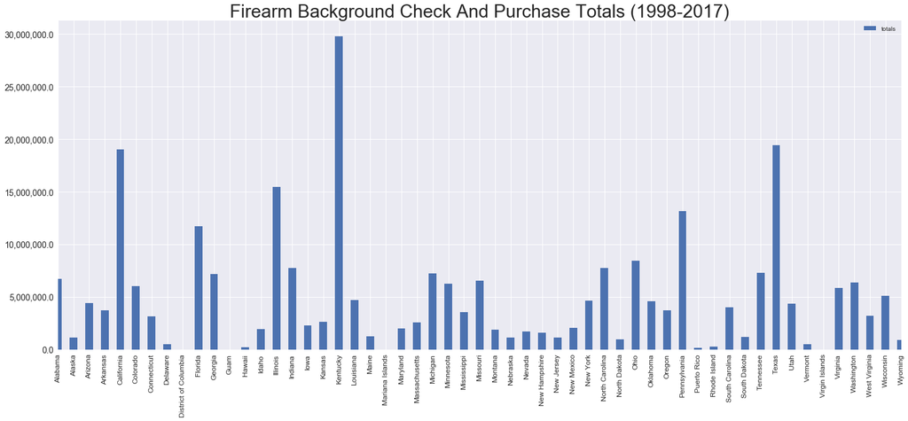

```python
# graph the sum off the entire dataset
state_total_tick_placement = pd.np.arange(len(gun_state_total))
plt.style.use('seaborn')
state_ax = gun_state_total.plot(kind='bar',figsize=(25,10))
state_ax.set_title("Firearm Background Check And Purchase Totals (1998-2017)", fontsize=30)
state_ax.set_yticklabels([ "{0:,.1f}".format(y) for y in state_ax.get_yticks() ], fontsize=14);
plt.setp(state_ax.get_xticklabels(), fontsize=12)
state_ax.set_xticks(state_total_tick_placement)
state_ax.set_xticklabels(gun_state_total.index)
state_ax.set_xlim(0, len(gun_state_total) - 1)
state_ax.set_xlabel("")
```

Note, Kentucky, Texas, and California have the most firearm background checks done of all time.

```python
# Now lets look at purchases to total state population at a specific time, rather than just looking at totals for a long time frame
# Synchronize both dataframe at 2010
state_df1 = gun_df.query('month == "2010-04"').state.str.lower().tolist()
state_df = census_df_pop.iloc[3, 1:].index.str.lower().tolist()
```

```python
miss_state = []
def miss_states(state):
    for s in state:
        if s not in state_df:
               miss_state.append(s)
    return miss_state

miss_state = miss_states(state_df1)
miss_state
```

```
['district of columbia',
 'guam',
 'mariana islands',
 'puerto rico',
 'virgin islands']
```

```python
gun_df['state'] = gun_df.state.str.lower()
```

```python
gun_tot_2010 = gun_df.query('month == "2010-04" & state != @miss_state')
```

```python
gun_tot_2016 = gun_df.query('month == "2016-04" & state != @miss_state')
```

```python
#gun_tot_2010.state = gun_tot_2010.state.str.capitalize()
```

```python
gun_tot_2010.head(2)
```

|  | month | state | permit | permit_recheck | handgun | long_gun | other | multiple | admin | prepawn_handgun | ... | rentals_long_gun | private_sale_handgun | private_sale_long_gun | private_sale_other | return_to_seller_handgun | return_to_seller_long_gun | return_to_seller_other | totals | year | months |
| --- | --- | --- | --- | --- | --- | --- | --- | --- | --- | --- | --- | --- | --- | --- | --- | --- | --- | --- | --- | --- | --- |
| 4895 | 2010-04 | alabama | 396.0 | 0.0 | 8727.0 | 8095.0 | 131.0 | 394 | 0.0 | 8.0 | ... | 0.0 | 0.0 | 0.0 | 0.0 | 0.0 | 0.0 | 0.0 | 20791 | 2010 | 4 |
| 4896 | 2010-04 | alaska | 0.0 | 0.0 | 2650.0 | 3136.0 | 64.0 | 135 | 0.0 | 10.0 | ... | 0.0 | 0.0 | 0.0 | 0.0 | 0.0 | 0.0 | 0.0 | 6411 | 2010 | 4 |

2 rows × 29 columns

```python
# find the totals column in this dataset
#gun_tot_2010.iloc[:,-3]
```

```python
gun_tot_2010.set_index('state', inplace = True)
```

```python
# make the labels consistent to the other labels.  lowercase makes it easier for the system to find.
census_df_pop.columns = census_df_pop.columns.str.lower()
```

```python
len(gun_tot_2010)
```

```
50
```

```python
# Calcluate the high gun per capita
avg_2010 = gun_tot_2010.iloc[:,-3]/census_df_pop.iloc[3, 1:]
```

```python
# length is the same as the gun_tot_2010, our division worked.
len(avg_2010)
```

```
50
```

```python
# clean and rename columns
avg_2010 = pd.DataFrame(avg_2010).reset_index()
avg_2010.columns = ['state', 'diff']
avg_2010
```

|  | state | diff |
| --- | --- | --- |
| 0 | alabama | 0.00434982 |
| 1 | alaska | 0.00902664 |
| 2 | arizona | 0.00259355 |
| 3 | arkansas | 0.00499431 |
| 4 | california | 0.00216756 |
| 5 | colorado | 0.00469439 |
| 6 | connecticut | 0.00445483 |
| 7 | delaware | 0.00160257 |
| 8 | florida | 0.00227612 |
| 9 | georgia | 0.00248409 |
| 10 | hawaii | 0.000707932 |
| 11 | idaho | 0.00498475 |
| 12 | illinois | 0.00420314 |
| 13 | indiana | 0.00389154 |
| 14 | iowa | 0.0031907 |
| 15 | kansas | 0.00333985 |
| 16 | kentucky | 0.0486848 |
| 17 | louisiana | 0.0029499 |
| 18 | maine | 0.00381899 |
| 19 | maryland | 0.00121104 |
| 20 | massachusetts | 0.00133606 |
| 21 | michigan | 0.00297289 |
| 22 | minnesota | 0.00496821 |
| 23 | mississippi | 0.00326964 |
| 24 | missouri | 0.0043896 |
| 25 | montana | 0.00845651 |
| 26 | nebraska | 0.00226738 |
| 27 | nevada | 0.00344152 |
| 28 | new hampshire | 0.00524964 |
| 29 | new jersey | 0.000479419 |
| 30 | new mexico | 0.00417594 |
| 31 | new york | 0.00102724 |
| 32 | north carolina | 0.00245168 |
| 33 | north dakota | 0.00553977 |
| 34 | ohio | 0.00271417 |
| 35 | oklahoma | 0.00473163 |
| 36 | oregon | 0.00418447 |
| 37 | pennsylvania | 0.00395587 |
| 38 | rhode island | 0.00113912 |
| 39 | south carolina | 0.00312213 |
| 40 | south dakota | 0.00560196 |
| 41 | tennessee | 0.00479869 |
| 42 | texas | 0.00258543 |
| 43 | utah | 0.0395787 |
| 44 | vermont | 0.00328091 |
| 45 | virginia | 0.00551642 |
| 46 | washington | 0.00413649 |
| 47 | west virginia | 0.00603348 |
| 48 | wisconsin | 0.00289626 |
| 49 | wyoming | 0.00711997 |

```python
avg_2010= avg_2010.fillna(0)
```

```python
avg_2010['diff'].argmax()
```

```
16
```

```python
# what is index 16?
avg_2010.iloc[16,:]
```

```
state     kentucky
diff     0.0486848
Name: 16, dtype: object
```

Kentucky is the winner for having the most background checks against its state population.

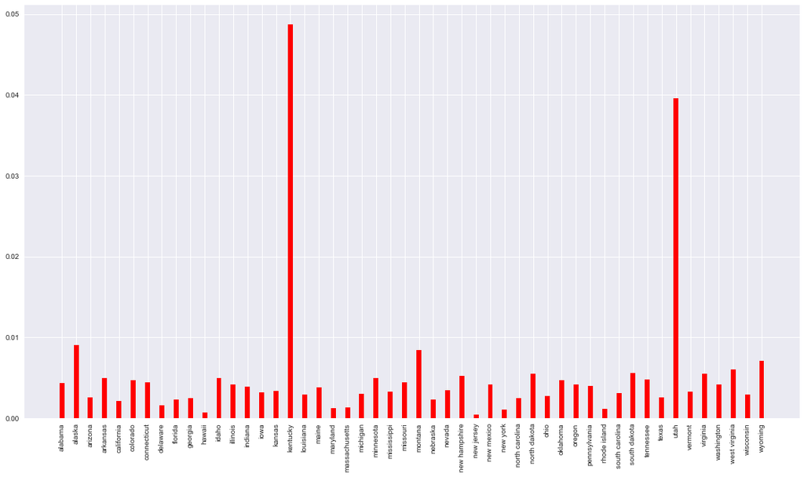

```python
width = .35

fig = plt.figure(figsize=(15,8))
ax = fig.add_axes([0,0,1,1])
labels = avg_2010['state']
y = avg_2010['diff']
ax.bar(labels, y, width, color='r')
plt.margins(0.05)
plt.xticks(labels, rotation='vertical')
plt.show()
```

Interestingly, while Kentucky, Texas, and California had the top three most checks done of all time, it is not the same against the population of the state. Kentucky has done more background checks against its population than Texas and California. While Utah is almost not even close to having a long record of doing background checks, it does a lot against its population. It must have a small population. Indeed, Utah has a small population in 2010 of '2,763,885' compared to a lot of the other states. Kentucky also has a small population compared to the others.

```python
#population of Utah in 2010
census_df['Utah'][3]
```

```
'2,763,885'
```

```python
#population of Kentucky in 2010
census_df['Kentucky'][3]
```

```
'4,339,367'
```

```python
#population of California in 2010
census_df['California'][3]
```

```
'37,253,956'
```

```python
# make the labels consistent to the other labels.  lowercase makes it easier for the system to find.
census_df.columns = census_df.columns.str.lower()
```

```python
#Transpose Census data and remove the index on Fact
df_census_T = census_df.T.reset_index()
```

```python
# make the labels consistent to the other labels.  lowercase makes it easier for the system to find.
df_census_T.columns = df_census_T.columns.str.lower()
```

```python
df_census_T.columns = df_census_T.iloc[0,:]
df_census_T.drop([0], inplace=True)
```

```python
df_census_T.set_index('population', inplace=True)
```

```python
avg_2010.set_index('state', inplace=True)
```

```python
df_census_join = df_census_T.join(avg_2010, how='inner' )
```

```python
# These are the columns we are going to graph against checks per state population
fact = df_census_join.iloc[:, [15, 16, 17, 18, 19, 20, 21, 23, -1]]
fact.head(1)
```

| population | Asian alone, percent, July 1, 2016, (V2016) | Native Hawaiian and Other Pacific Islander alone, percent, July 1, 2016, (V2016) | Two or More Races, percent, July 1, 2016, (V2016) | Hispanic or Latino, percent, July 1, 2016, (V2016) | White alone, not Hispanic or Latino, percent, July 1, 2016, (V2016) | Veterans, 2011-2015 | Foreign born persons, percent, 2011-2015 | Housing units, April 1, 2010 | diff |
| --- | --- | --- | --- | --- | --- | --- | --- | --- | --- |
| alabama | 1.40% | 0.10% | 1.60% | 4.20% | 65.80% | 363,170 | 3.50% | 2,171,853 | 0.00435 |

```
Asian alone, percent, July 1, 2016,  (V2016)
```

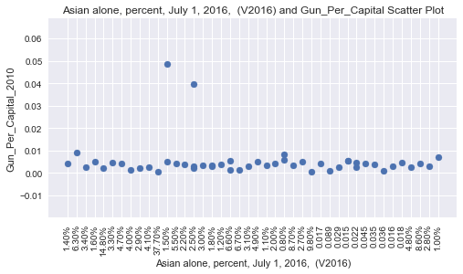

```
Native Hawaiian and Other Pacific Islander alone, percent, July 1, 2016,  (V2016)
```

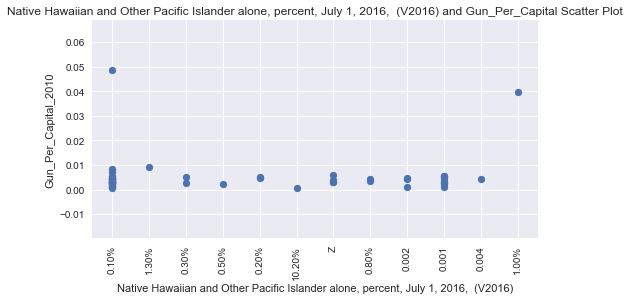

```
Two or More Races, percent, July 1, 2016,  (V2016)
```

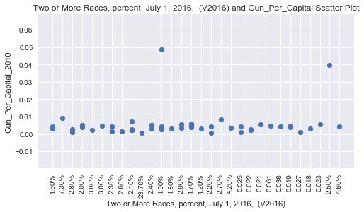

```
Hispanic or Latino, percent, July 1, 2016,  (V2016)
```

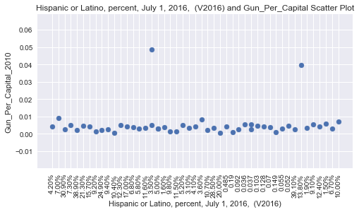

```
White alone, not Hispanic or Latino, percent, July 1, 2016,  (V2016)
```

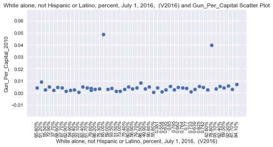

```
Veterans, 2011-2015
```

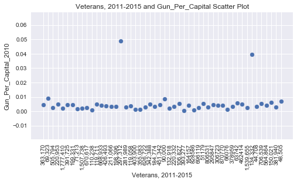

```
Foreign born persons, percent, 2011-2015
```

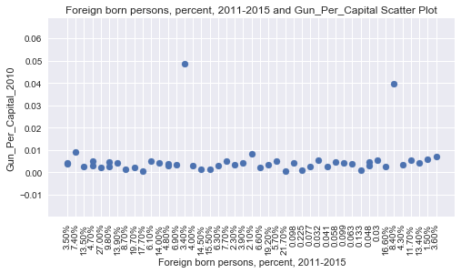

```
Housing units, April 1, 2010
```

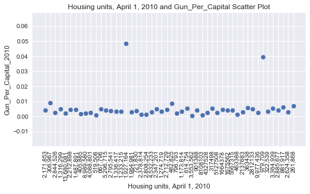

```
diff
```

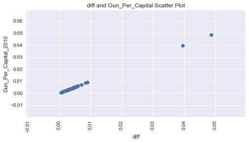

```python
#Kept only 10 variable at random in fact table to create scatter plot with gun per capital.
fact = df_census_join.iloc[:, [15, 16, 17, 18, 19, 20, 21, 23, -1]]

imp = fact.columns

for col in imp:
    plt.figure(figsize=(8,4))
    print(col)
    plt.scatter(fact[col], fact['diff'], label =col)

    plt.title(col+" and Gun_Per_Capital Scatter Plot")
    plt.ylabel("Gun_Per_Capital_2010")
    plt.xlabel(col)
    plt.xticks(label =col, rotation='vertical')
    plt.grid(True)
    plt.show()
```

Interestingly, when comparing the specific per captia amount of gun purchases with permit against the state amount, the graphs are nearly identical with very minor differences to each other. We find that the one that is really different in trend is the Native Hawaiian and Other Pacific Islander population. The data points are more clustered.

### Research Question 2 : Which states have had the highest growth in gun registrations?

```python
# Continue to explore the data to address your additional research
# questions.

# Check the total of each state by month and the group by and sum
checks_by_state = gun_df.groupby(['state', 'month'])['permit'].sum().reset_index()
state_totals = checks_by_state.groupby('state')['permit'].sum()
#state_total_tick_placement = pd.np.arange(len(state_totals))
#checks_by_state.month.unique()
```

```python
# put state as the index
checks_by_state_ = checks_by_state.set_index(['state'])
checks_by_state_
```

| state | month | permit |
| --- | --- | --- |
| alabama | 1998-11 | 0.0 |
| alabama | 1998-12 | 0.0 |
| alabama | 1999-01 | 0.0 |
| alabama | 1999-02 | 0.0 |
| alabama | 1999-03 | 0.0 |
| ... | ... | ... |
| wyoming | 2017-05 | 435.0 |
| wyoming | 2017-06 | 350.0 |
| wyoming | 2017-07 | 279.0 |
| wyoming | 2017-08 | 408.0 |
| wyoming | 2017-09 | 280.0 |

12485 rows × 2 columns

```python
#arrange the data so it is better for a graph
checks_by_state_piv = checks_by_state.pivot(index='month', columns='state', values='permit')
checks_by_state_piv
```

| state month | alabama | alaska | arizona | arkansas | california | colorado | connecticut | delaware | district of columbia | florida | ... | tennessee | texas | utah | vermont | virgin islands | virginia | washington | west virginia | wisconsin | wyoming |
| --- | --- | --- | --- | --- | --- | --- | --- | --- | --- | --- | --- | --- | --- | --- | --- | --- | --- | --- | --- | --- | --- |
| 1998-11 | 0.0 | 4.0 | 0.0 | 0.0 | 434.0 | 0.0 | 17.0 | 0.0 | 0.0 | 0.0 | ... | 0.0 | 0.0 | 0.0 | 0.0 | 0.0 | 0.0 | 1.0 | 3.0 | 0.0 | 8.0 |
| 1998-12 | 0.0 | 0.0 | 1733.0 | 0.0 | 4932.0 | 0.0 | 2800.0 | 0.0 | 0.0 | 0.0 | ... | 0.0 | 5324.0 | 0.0 | 0.0 | 0.0 | 0.0 | 668.0 | 2.0 | 0.0 | 113.0 |
| 1999-01 | 0.0 | 0.0 | 1718.0 | 1.0 | 7311.0 | 0.0 | 3010.0 | 0.0 | 0.0 | 0.0 | ... | 0.0 | 5792.0 | 0.0 | 0.0 | 0.0 | 0.0 | 800.0 | 0.0 | 0.0 | 67.0 |
| 1999-02 | 0.0 | 0.0 | 1828.0 | 10.0 | 5715.0 | 0.0 | 4526.0 | 0.0 | 0.0 | 0.0 | ... | 0.0 | 5444.0 | 0.0 | 0.0 | 0.0 | 0.0 | 805.0 | 6.0 | 0.0 | 150.0 |
| 1999-03 | 0.0 | 0.0 | 2193.0 | 25.0 | 7591.0 | 0.0 | 3689.0 | 0.0 | 0.0 | 0.0 | ... | 0.0 | 5818.0 | 0.0 | 0.0 | 0.0 | 0.0 | 1218.0 | 11.0 | 0.0 | 171.0 |
| ... | ... | ... | ... | ... | ... | ... | ... | ... | ... | ... | ... | ... | ... | ... | ... | ... | ... | ... | ... | ... | ... |
| 2017-05 | 18538.0 | 247.0 | 6628.0 | 4137.0 | 58722.0 | 5408.0 | 8101.0 | 863.0 | 10.0 | 19014.0 | ... | 23584.0 | 24168.0 | 16351.0 | 0.0 | 55.0 | 1148.0 | 14176.0 | 2141.0 | 13117.0 | 435.0 |
| 2017-06 | 19508.0 | 242.0 | 6505.0 | 3033.0 | 60142.0 | 4920.0 | 8290.0 | 533.0 | 17.0 | 18831.0 | ... | 16722.0 | 23877.0 | 14721.0 | 0.0 | 126.0 | 728.0 | 12964.0 | 1889.0 | 11645.0 | 350.0 |
| 2017-07 | 18042.0 | 222.0 | 5606.0 | 2564.0 | 52610.0 | 4392.0 | 6387.0 | 305.0 | 19.0 | 16978.0 | ... | 19766.0 | 19006.0 | 11902.0 | 0.0 | 103.0 | 1139.0 | 10910.0 | 1798.0 | 10275.0 | 279.0 |
| 2017-08 | 19733.0 | 247.0 | 6733.0 | 3313.0 | 59528.0 | 5219.0 | 5896.0 | 288.0 | 19.0 | 18362.0 | ... | 14548.0 | 22971.0 | 15013.0 | 0.0 | 81.0 | 2220.0 | 12068.0 | 2028.0 | 12647.0 | 408.0 |
| 2017-09 | 16717.0 | 209.0 | 5069.0 | 2935.0 | 57839.0 | 4356.0 | 4343.0 | 275.0 | 1.0 | 10784.0 | ... | 16887.0 | 31390.0 | 12094.0 | 0.0 | 1.0 | 585.0 | 11451.0 | 1668.0 | 12224.0 | 280.0 |

227 rows × 55 columns

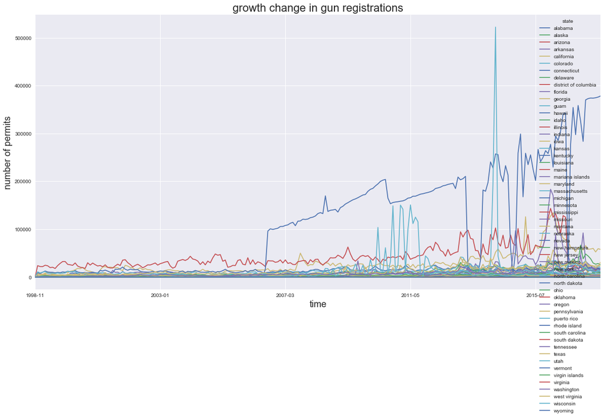

```python
# start graphing the specific data
checks_by_state_piv.plot(figsize=(20,10))
label = 'growth change in gun registrations'
plt.title(label, fontsize=22, loc='center')
plt.xlabel('time', fontsize=18)
plt.ylabel('number of permits', fontsize=18)
plt.show()
```

This is intersting but a bit messy to read and understand. Lets do more anaylsis and clean it up.

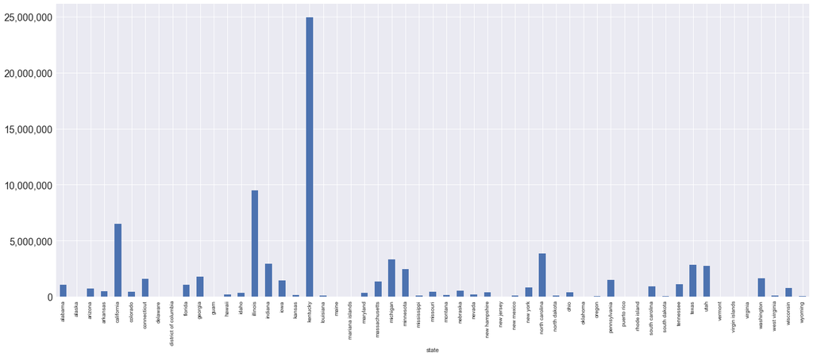

```python
#plt.bar(state_totals.index, state_totals)
ax = state_totals.plot(kind='bar',figsize=(25,10))
ax.set_yticklabels([ "{0:,.0f}".format(y) for y in ax.get_yticks() ], fontsize=18);
```

From this graph we can see that top selling states with rapid growth are 'Kentucky', 'Illinois','California','North carolina', and 'Michigan'. We can uses this data to filter out other lines in our prior graph.

```python
top_change = checks_by_state_piv[['kentucky', 'illinois','california','north carolina', 'michigan']]
```

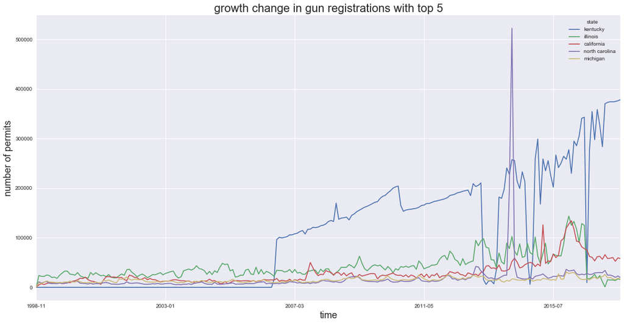

```python
top_change.plot(figsize=(20,10))
label = 'growth change in gun registrations with top 5'
plt.title(label, fontsize=22, loc='center')
plt.xlabel('time', fontsize=18)
plt.ylabel('number of permits', fontsize=18)
plt.show()
```

This graph shows, Kentucky having the most rapid growth. Interestingly, the state only really picks up at around 2006 and was was nearly non existent prior to. North Carolina had a huge spike in around 2014. I wonder what that is about? The The states of North Carolina (besides the big bump), Illinois, and Michigan have been at a steady growth level that changes nearly at the same rate.

### Research Question 3 : What is the overall trend of gun purchases?

[figure not shown]

```python
# sum total increasing by month from Nov 1998 to Sept 2017
totals = gun_df.groupby("month")["totals"].sum()

tick_placement = pd.np.arange(2, len(totals), 12)
plt.style.use('seaborn')
ax = totals.plot(kind='bar',figsize=(25,10))
ax.set_title("Firearm Background Checks Per Capita from November 1998 to September 2017", fontsize=30)
ax.set_yticklabels([ "{0:,.0f}".format(y) for y in ax.get_yticks() ], fontsize=14);
plt.setp(ax.get_xticklabels(), rotation=0, fontsize=14)
ax.set_xticks(tick_placement)
ax.set_xticklabels([ totals.index[i].split("-")[0] for i in tick_placement ])
ax.set_xlim(0, len(totals) - 1)
ax.set_xlabel("")
```

The graph shows in the early years between 1999 to 2004, background checks with purchases were done at a constant level. Beyond that date, background check have been increasing and growing at a linear rate. However, in this trend, there are about two outliers, one around 2012-2013, andone around 2015-2016.

## Conclusions

> In reiteration:
- What census data is most associated with high gun per capita?

> We find, Kentucky, Texas, and California have the most firearm background checks done of all time from 1998-2017. Interestingly, while Kentucky, Texas, and California had the top three most checks done of all time, it is not the same against the population of the state. Kentucky had a higher number again, and Kentucky had a rate of doing background checks against its population of 0.0486848. Kentucky has done more background checks against its population than Texas and California. Texas had a proportion of 0.002585 and California had a proportion of 0.002168. While Utah is almost not even close to having a long record of doing background checks, it does a lot of checks against its population. Utah had a proportion of 0.039579. It must have a small population which makes the difference in giving it a high scoring proportion. Indeed, Utah has a small population in 2010 of '2,763,885' compared to a lot of the other states. Kentucky also has a small population compared to the others.

> We find when we test more of the Census categories at random against the checks per state population, as shown in the scatterplots, the trends seem very similar. Indeed, the graphs are nearly identical with very minor differences to each other. We find that the one that is really different in trend is the Native Hawaiian and Other Pacific Islander population. The data points are more clustered. However, this analysis is limited, as we only compared the 2010 official census when there are about 5 years of population differences. If we had time to use the 2016 population, we could find a difference. But even that is limited and possibly biased since it is an estimate and may not have had the same procedures in making as the official 2010 census count.
- Which states have had the highest growth in gun registrations?

> The graph we made shows, Kentucky having the most rapid growth. Interestingly, the state only really picks up at around 2006 and was nearly nonexistent prior to. North Carolina had a huge spike in around 2014. I wonder what that is about? It would be interesting to compare it to the country's mood, trends, and news. The states of North Carolina (besides the big bump), Illinois, and Michigan have been at a steady growth level that changes nearly at the same rate. This process is a bit limited, as machine learning would be needed to find the growth rate in registrations rather than estimate by a graph. Machine learning could find the best fit line to represent the graph and assign a number.
- What is the overall trend of gun purchases?

> The graph shows in the early years between 1999 to 2004, background checks with purchases were done at a constant level. Essentially people did the same number despite population growth. Beyond that period of time, background check has been increasing and growing at a linear rate. However, in this trend, there are about two outliers, one around 2012-2013, and one around 2015-2016. Again, it would be interesting to compare it to the country's mood, trends, and news to see why these are outliers.!

> **Tip**: Once you are satisfied with your work, you should save a copy of the report in HTML or PDF form via the **File** > **Download as** submenu. Before exporting your report, check over it to make sure that the flow of the report is complete. You should probably remove all of the "Tip" quotes like this one so that the presentation is as tidy as possible. Congratulations!

References

https://github.com/Shilin-Li/Investigate_the_FBI_Gun_Dataset/blob/master/Investigate_FBI_Gun_Dataset_20180108.ipynb

https://github.com/imsingla/Investigate-FBI-NCIS-Gun-Data/blob/master/investigate-a-dataset.ipynb

https://github.com/ciph3rwoman/Investigating-FBI-Gun-Dataset/blob/master/Investigate_a_Dataset.ipynb

https://github.com/BuzzFeedNews/nics-firearm-background-checks/blob/master/README.md